# *Physalia* global population genomics: pilot dataset

Samuel H. Church

Initiated: March, 2023

# Samples

This pilot population genomic study uses 8 samples from 4 locations.

| sample | location |
| --- | --- |
| 3-Japan | Japan |
| 6-Japan | Japan |
| Bermuda-67 | Bermuda |
| Bermuda-94 | Bermuda |
| Physalia-NA22 | Guam |
| Physalia-NA24 | Guam |
| YPM110251 | Florida |
| YPM110254 | Florida |

# Mapping

Reads were trimmed with `trimmomatic` and mapped with `bwa mem`.

We first mapped to the 2021 assembly of an Atlantic genome, done by Zack lewis.

Mapping statistics were evaluated with `samtools flagstat`.

| stat | Japan.6 | Japan.3 | Bermuda_67 | Bermuda_94 | Physalia.NA22 | Physalia.NA24 | YPM110251 | YPM110254 |
| --- | --- | --- | --- | --- | --- | --- | --- | --- |
| in total (QC-passed reads) | 521674275 | 529992256 | 557164319 | 708760531 | 1399705543 | 595031924 | 566961352 | 651321495 |
| secondary | 0 | 0 | 0 | 0 | 0 | 0 | 0 | 0 |
| supplementary | 28070561 | 30204584 | 24522267 | 30615407 | 71941273 | 27304320 | 15614888 | 15515573 |
| duplicates | 0 | 0 | 0 | 0 | 0 | 0 | 0 | 0 |
| mapped | 506368272 | 513053085 | 549794544 | 700152083 | 1363524877 | 579430907 | 557969171 | 644144981 |
| paired in sequencing | 493603714 | 499787672 | 532642052 | 678145124 | 1327764270 | 567727604 | 551346464 | 635805922 |
| read1 | 246801857 | 249893836 | 266321026 | 339072562 | 663882135 | 283863802 | 275673232 | 317902961 |
| read2 | 246801857 | 249893836 | 266321026 | 339072562 | 663882135 | 283863802 | 275673232 | 317902961 |
| properly paired | 408113046 | 388298522 | 450025530 | 579832478 | 1132723358 | 487084356 | 489887844 | 589320540 |
| with itself and mate mapped | 475156288 | 478135356 | 522615788 | 666425224 | 1283936988 | 549436394 | 539986606 | 626949448 |
| singletons | 3141423 | 4713145 | 2656489 | 3111452 | 7646616 | 2690193 | 2367677 | 1679960 |
| with mate mapped to a different chr | 64935322 | 87716524 | 70190074 | 84384672 | 147193836 | 60101776 | 48446340 | 36086646 |
| with mate mapped to a different chr (mapQ>=5) | 16518855 | 22327561 | 22992379 | 27939534 | 34575508 | 15019684 | 16232936 | 10923188 |
| percent mapped | 97.07% | 96.80% | 98.68% | 98.79% | 97.42% | 97.38% | 98.41% | 98.90% |
| percent paired | 78.23% | 73.26% | 80.77% | 81.81% | 80.93% | 81.86% | 86.41% | 90.48% |

We also mapped to the 2023 assembly of a Pacfic genome, done by Ozren and Alex.

| stat | Japan.6 | Japan.3 | Bermuda_67 | Bermuda_94 | Physalia.NA22 | Physalia.NA24 | YPM110254 | YPM110251 |
| --- | --- | --- | --- | --- | --- | --- | --- | --- |
| total | 507146423 | 517704214 | 569908904 | 724802442 | 1369522195 | 580389668 | 666856894 | 581153391 |
| mapped | 505417025 | 515800105 | 567135299 | 721343493 | 1362303569 | 576198858 | 664035007 | 577548748 |
| properly paired | 446663476 | 425917436 | 428335958 | 556832174 | 1210320540 | 504570488 | 566517138 | 466944138 |
| percent mapped | 99.66% | 99.63% | 99.51% | 99.52% | 99.47% | 99.28% | 99.58% | 99.38% |
| percent paired | 88.07% | 82.27% | 75.16% | 76.83% | 88.38% | 86.94% | 84.95% | 80.35% |

# `picard`

Reads were then re-sorted by coordinate and deduplicated using `picard`

```bash
# java -jar $EBROOTPICARD/picard.jar SortSam \
#                 I={input} \
#                 O={output} \
#                 SORT_ORDER=coordinate 2> {log}

# java -jar $EBROOTPICARD/picard.jar MarkDuplicates \
#                 I={input} \
#                 O={output.DEDUP} \
#                 M={output.METRIC} \
#                 REMOVE_DUPLICATES=true 2> {log}
```

# `angsd` and `pcangsd`

`angsd` estimates genotype likelihoods from mapped reads, and was called as follows:

```bash
# angsd -GL 1 \ #estimate genotype likelihoods
#   -out pilot_genolike \ #output
#   -nThreads 25 \ #cores
#   -doGlf 2 \ #output likelihoods to a beagle type file
#   -doMajorMinor 1 \ #infer major and minor allele
#   -doMaf 2 \ #infer only major allele, sum over 3 possible minor alleles
#   -SNP_pval 1e-6 \ #remove sites with pval larger than 1e-6
#   -bam bam.filelist \ #input filelist
#   -minMapQ 30 \ #discard mapQ quality lower than 30
#   -minQ 20 \ #discard bases with qscore lower than 20
#   -doCounts 1 \ #estimate base frequencies
#   -doDepth 1 #output depth distribution
```

The bam.filelist reads as follows:

```bash
#  3-Japan_dedup.bam
#  6-Japan_dedup.bam
#  Bermuda-67_dedup.bam
#  Bermuda-94_dedup.bam
#  Physalia-NA22_dedup.bam
#  Physalia-NA24_dedup.bam
#  YPM110251_dedup.bam
#  YPM110254_dedup.bam
```

## depth distributions

`angsd` will print out the number of sites with a sequencing depth of 0,1,2,…

The maximum depth here is 100, all depths above that are binned at 100.

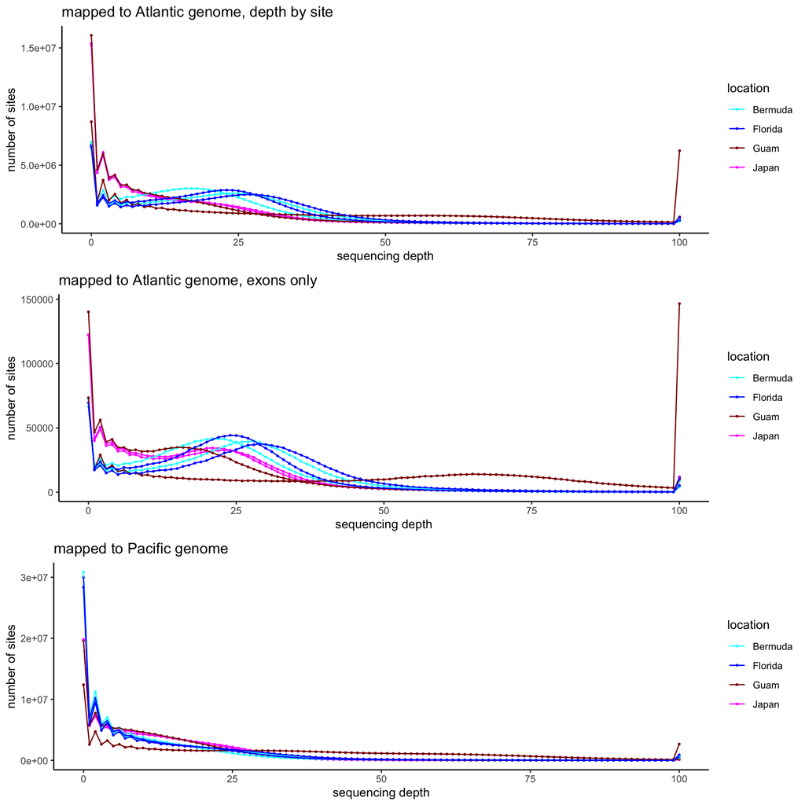

# PCA of genotype likelihoods

`pcangsd` was run as follows:

```bash
# pcangsd \
#   -b ~/scratch60/20230117_Phy_skim_variants/angsd/pilot_genolike.beagle.gz \ #beagle input, from angsd
#   -o pilot_pcangsd \ #output
#   --threads 14 \ #cores
#   --admix \ #estimate admixture and ancestral allele frequencies
#   --admix_alpha 5 #alpha value for regularization in admixture estimations
#       #= "small penalty on the admixture proportions (alpha)"
```

## eigenvalue loadings

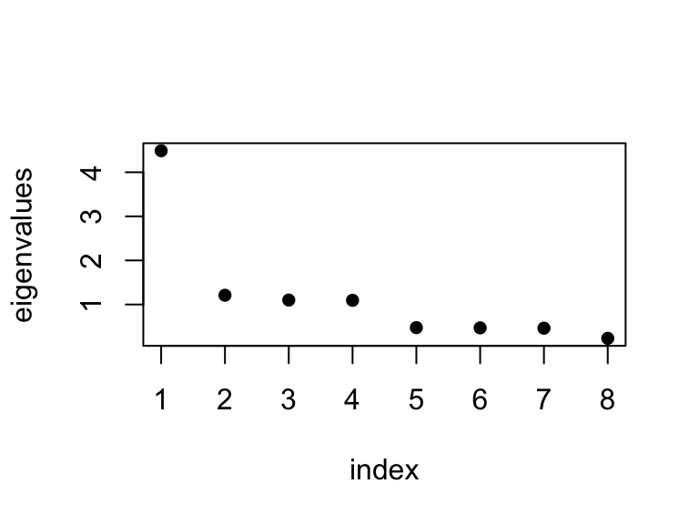

```r
# read in covariance
cov <- as.matrix(read.table("results/Atlantic/pilot_pcangsd.cov"))
# estimate eigenvectors and eigenvalues
e<-eigen(cov)

plot(e$values,ylab="eigenvalues",xlab="index",pch=16)
```

## principal component analysis

The results, mapping to the Atlantic genome.

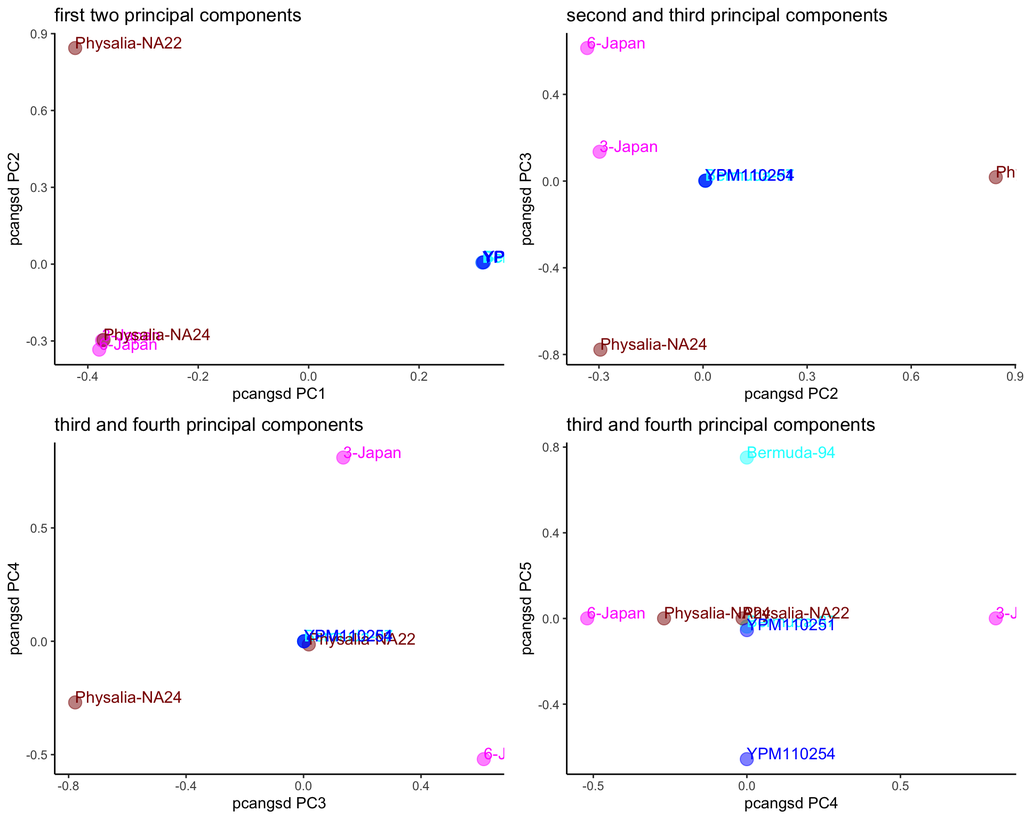

The results, mapping to the Atlantic genome, filtered to exons.

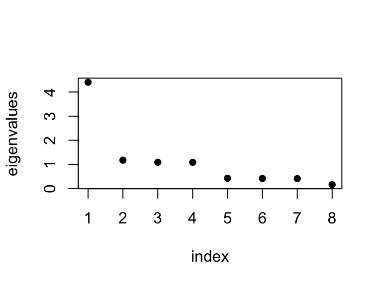

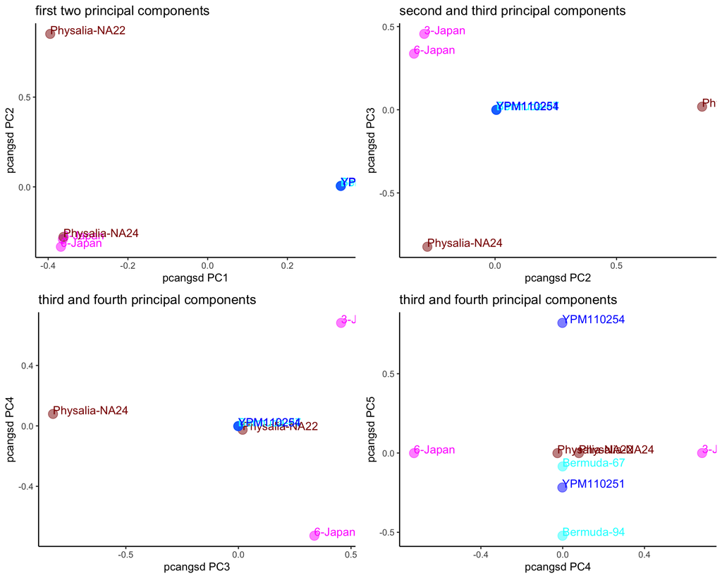

The results, mapping to the Pacific genome.

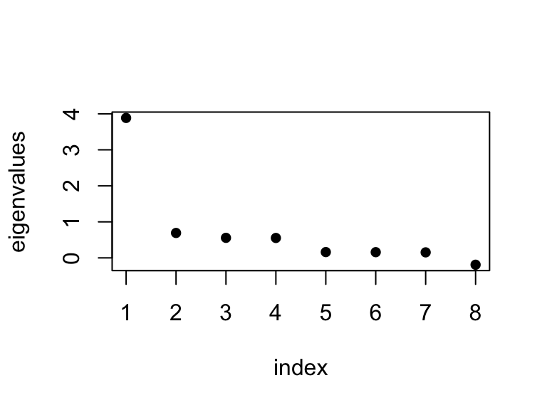

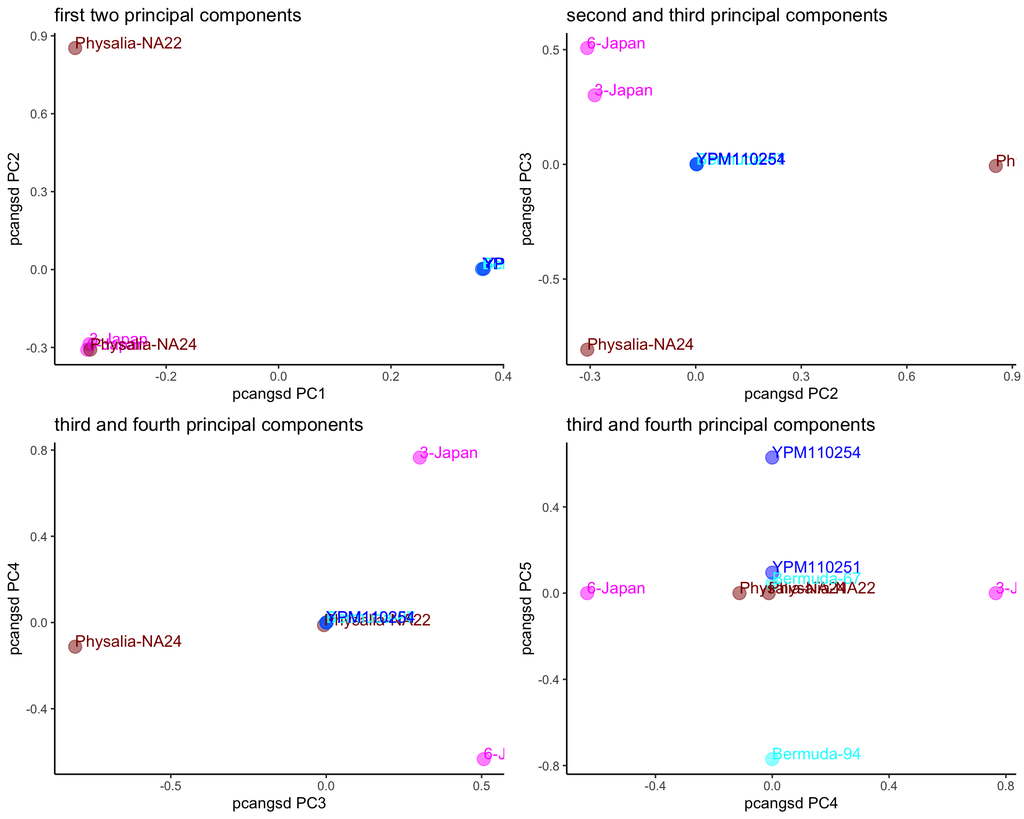

## admixture

`pcangsd` can also estimate admixture across populations.

Here we are using the first two principal components, mapping to the Pacific genome.

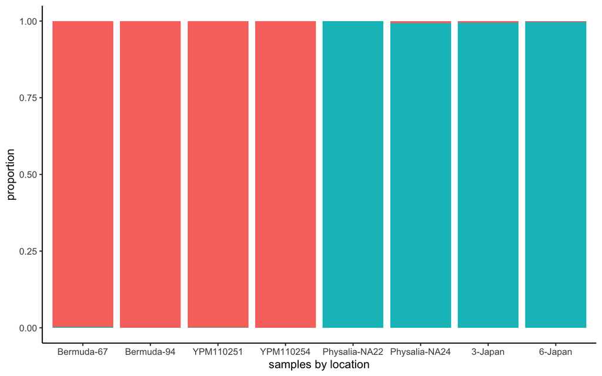

Here are the results, mapping to only exons. The number of populations have been chosen by `pcangsd` (2), and then fixed at 3, 4, and 5.

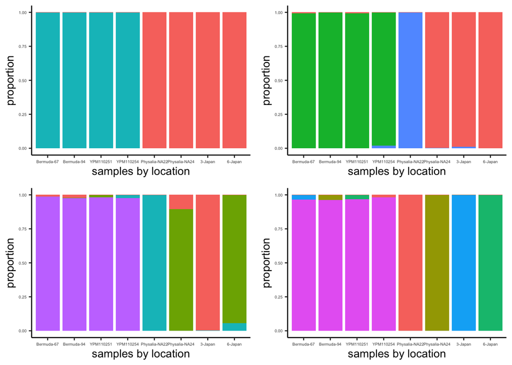

Here is the same plot, mapped to the Pacific genome.

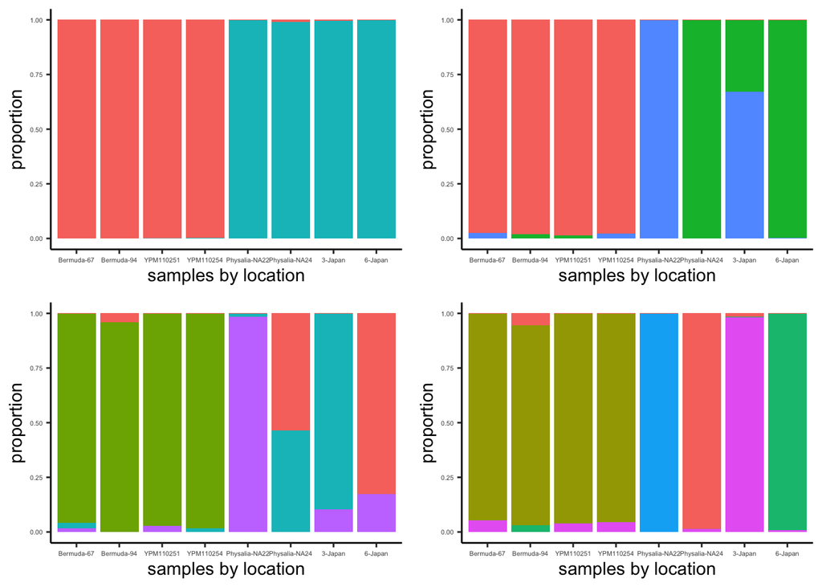

# Subsampling analysis

Sequencing depth as we subsample reads

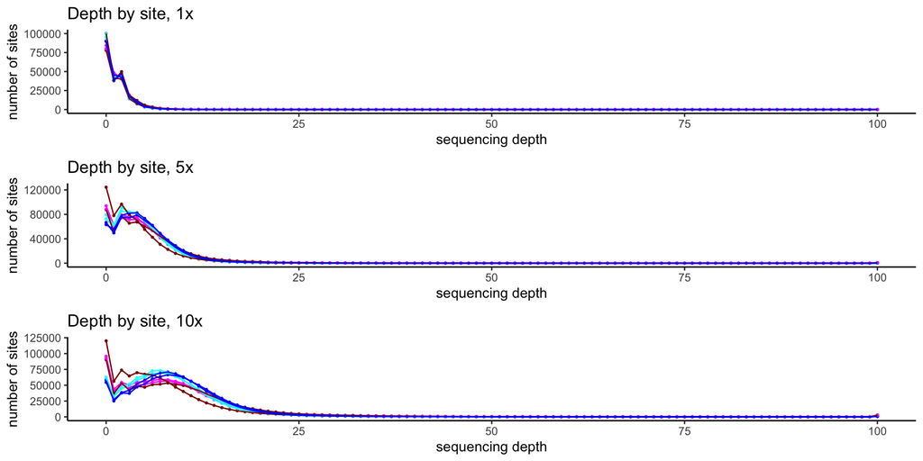

PCA as we subsample

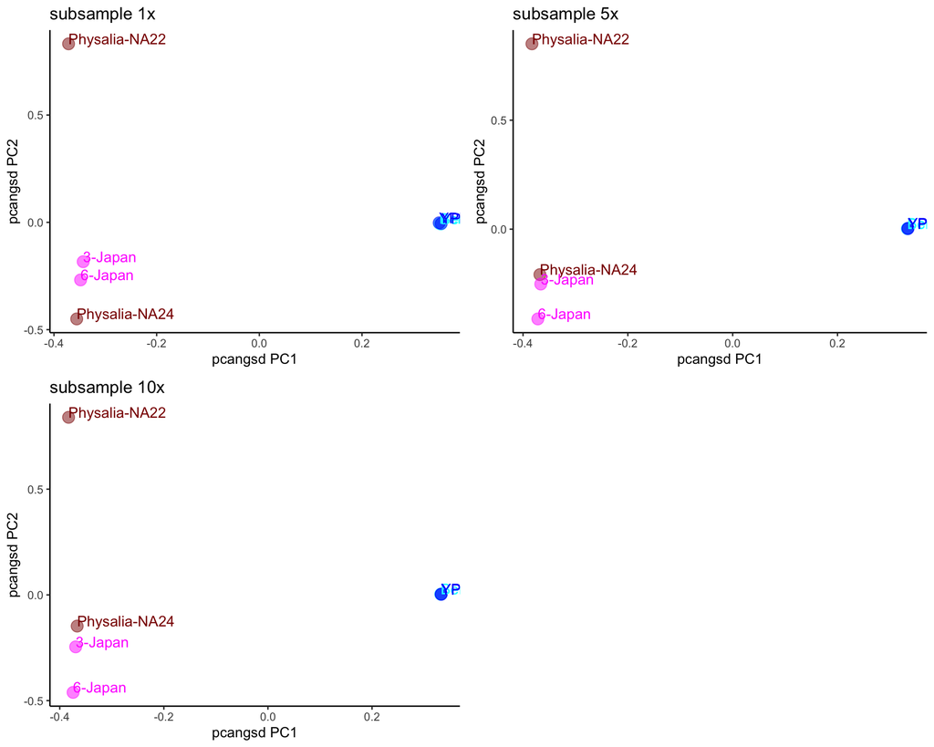

Admixture as we subsample

Subsampling to 1x

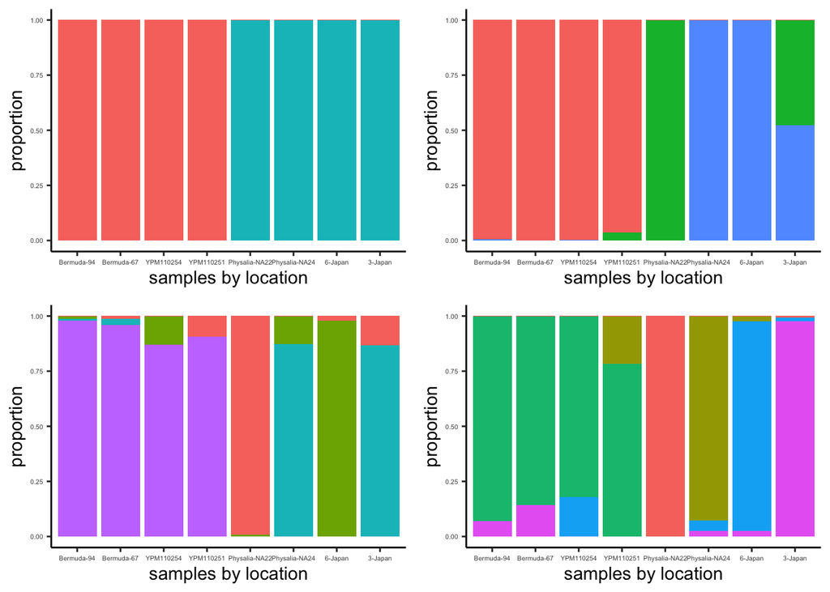

Subsampling to 5x

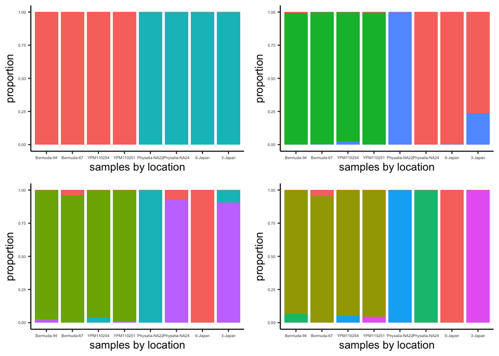

Subsampling to 10x

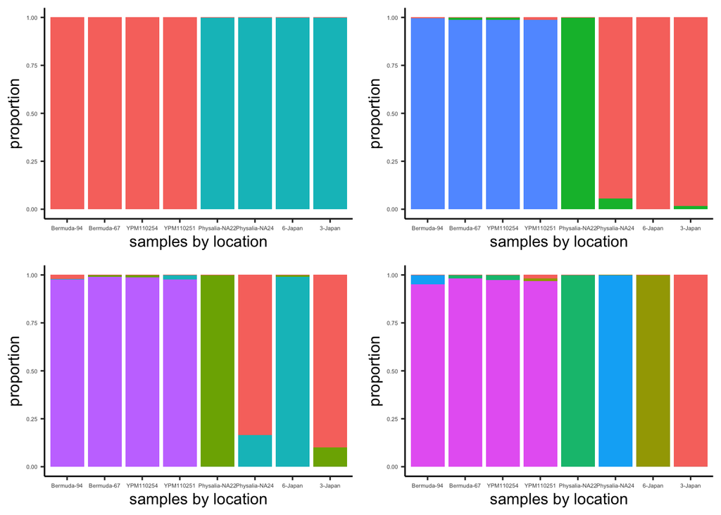

# Estimating parameters of diversity

Using `pixy`, we can estimate diversity between the Pacific and Atlantic populations. It was called as follows:

```bash
# tabix -p vcf {input.vcf.gz}
# pixy --stats pi fst dxy --vcf {input.vcf.gz} --populations {populations file} --n_cores 8 --window_size 500000 --output_folder {output}
```

Here we examine how these numbers vary as we change the sampling procedure.

| subsampling | Fst | Dxy | pi |
| --- | --- | --- | --- |
| 1x | 0.1438 | 0.0108 | 0.0025 |
| 5x | 0.5266 | 0.0119 | 0.0044 |
| 10x | 0.5319 | 0.0130 | 0.0054 |